# Part II - Factors affecting duration on FordBike

## by Chukwuebuka Ifechukwu

## Investigation Overview

This presentation will explore the data from Ford Gobike on the different individuals that took trips and from there determine the various factors that are necessary to predict if an individual will go on a trip for a long duration of time. Factors such as age, gender, user type and days of the week will be explored and see what correlation exists between them and the duration of time.

## Dataset Overview

The dataset contains information about individual rides made in a bike-sharing system covering the greater San Francisco Bay area, information such as duration, start and end time, gender, user type as well as start and end station are recorded.

## Duration

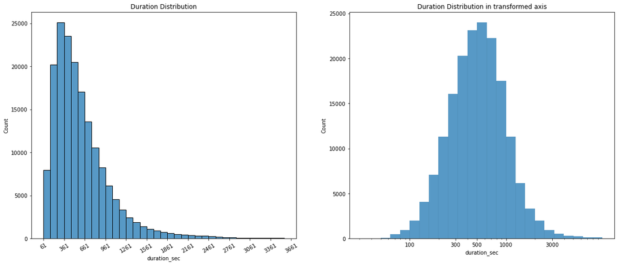

## Age

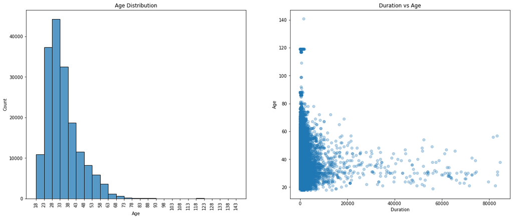

## Gender

With gender, we see that Men have the significantly higher number in comparison to Female and other gender and they seem to all fall within the same age range. For the duration, it can be seen that on average the other gender went on longer trips in compared to the male and female genders.

[figure not shown]

## User type

The user type indicates a fascinating information because from the count, 90% of the users in the dataset are subscribers but in comparing the average duration, it would seem that it was the customer type users who went on longer trips with the bikes as depicted in the box plot.

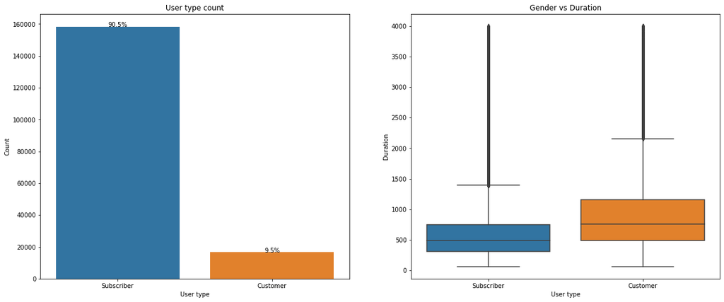

## Weekdays

By looking at the weekdays and the average duration, we are able to see that the most duration were done on the weekends in particular to Sunday. This of course correlates with the knowledge that most people are free on Sundays/weekends which will allow them to go on longer trips around San Francisco.

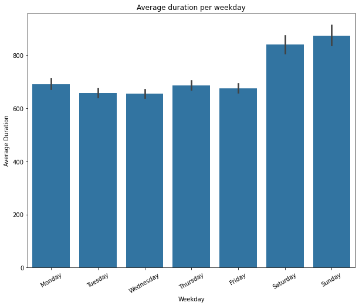